# Spatial model for redundancy

Erick Calderón-Morales

March 28, 2019

# Multiple regression model for Redundancy, Effect traits

Erick Calderón-Morales

March 30, 2019

```r
#Paquetes
library(kableExtra)
library(lattice)
library(tidyverse)
library(PerformanceAnalytics)
library(janitor)
source("C:/tesis_catie/Calderon_CATIE/scripts/functions/HighstatLibV10.R")
library(ggbiplot)
library(GGally)
library(INLA)
```

# Objetivo

Realizar un modelo linear multiple para los datos de Redundancia funcional Ref: Capitulo 8 Zuur et al.

```r
#Load data
dredun_eff <- read.csv("C:/tesis_catie/Calderon_CATIE/data/resultados_csv/data_indices_eff_redundancy.csv", header=T)
dredun_eff <- clean_names(dredun_eff) %>%
  select(-c(d))

dparcelas <- read.csv("C:/tesis_catie/Calderon_CATIE/data/clean/data_posicion_parcelas.csv", header = T)
dparcelas <- clean_names(dparcelas)

denv <- read.csv("C:/tesis_catie/Calderon_CATIE/data/clean/data_enviroment_worldclim_clean.csv", header = T, row.names = 1)
denv <- denv %>%
  clean_names() %>%
    select(-c(crtm_90_x,crtm_90_y,forest_type, slope_per,slope_deg))

#Standarize data
denvi_est <-  scale(denv,center = F, scale = T )
denvi_est <- rownames_to_column(as.data.frame(denvi_est),var= "plot")
```

# Join Data sets

```r
dfull  <- left_join(dredun_eff, dparcelas,by=c("plot") ) %>%
  left_join(.,denvi_est, by=c("plot") )
#Ordenar columnas
dfull_est <- dfull %>% select(plot, forest_type,longitude,latitude,crtm_90_x,crtm_90_y,n,redundancy,u , q, everything())
glimpse(dfull_est)
```

```
## Observations: 127
## Variables: 27
## $ plot           <chr> "F10P1", "F10P2", "F10P3", "F10P4", "F11P1", "F...
## $ forest_type    <fct> P.macroloba, P.macroloba, P.macroloba, P.macrol...
## $ longitude      <dbl> -84.13907, -84.14223, -84.14690, -84.14741, -84...
## $ latitude       <dbl> 10.58515, 10.58890, 10.58497, 10.58649, 10.7037...
## $ crtm_90_x      <dbl> 484782.4, 484435.9, 483925.3, 483869.0, 479984....
## $ crtm_90_y      <dbl> 1170464, 1170880, 1170445, 1170614, 1183586, 11...
## $ n              <int> 12, 19, 13, 15, 21, 20, 17, 15, 13, 16, 15, 16,...
## $ redundancy     <dbl> 0.8725523, 0.8979476, 0.8711145, 0.8523120, 0.8...
## $ u              <dbl> 0.12744773, 0.10205244, 0.12888546, 0.14768803,...
## $ q              <dbl> 0.10335379, 0.09021181, 0.09405633, 0.09045544,...
## $ sand           <dbl> 0.8160510, 0.6767592, 0.9087578, 0.5842842, 0.5...
## $ limo           <dbl> 1.2102600, 1.0981989, 1.5458830, 1.6579441, 0.7...
## $ clay           <dbl> 0.8581029, 1.0172463, 0.6594220, 0.8978391, 1.2...
## $ p_h            <dbl> 1.0214836, 0.9562825, 1.2388205, 1.2822879, 0.9...
## $ acidity        <dbl> 2.31038300, 1.08199755, 0.07001161, 0.49962828,...
## $ ca             <dbl> 2.32213037, 0.32208520, 5.72480464, 3.53774225,...
## $ mg             <dbl> 1.7259923, 0.4432876, 3.5651645, 2.7257474, 0.2...
## $ k              <dbl> 2.4588529, 0.6705962, 3.1294491, 1.1176604, 0.5...
## $ p              <dbl> 0.6014830, 0.9623727, 0.5413347, 0.3909639, 0.9...
## $ organic_matter <dbl> 0.5100446, 0.7900463, 0.5344431, 0.2207482, 0.7...
## $ elev           <dbl> 0.3662337, 0.6278292, 0.5149301, 0.6058001, 0.1...
## $ prec           <dbl> 0.9986238, 1.0735019, 1.0435506, 1.0203384, 0.9...
## $ precdriest     <dbl> 0.9154796, 1.0164516, 0.9760628, 0.9760628, 0.5...
## $ preccv         <dbl> 1.0069702, 0.9764559, 1.0069702, 1.0069702, 1.1...
## $ temp           <dbl> 1.0078616, 0.9919898, 0.9959578, 0.9999257, 1.0...
## $ tempmin        <dbl> 1.0075683, 0.9923789, 0.9974420, 0.9974420, 1.0...
## $ tempsd         <dbl> 3.2815711, 0.9528710, 0.9577326, 0.9577326, 0.9...
```

# Data exploration

## PCA sin variables de respuesta

```r
ncol(denvi_est)
```

```
## [1] 18
```

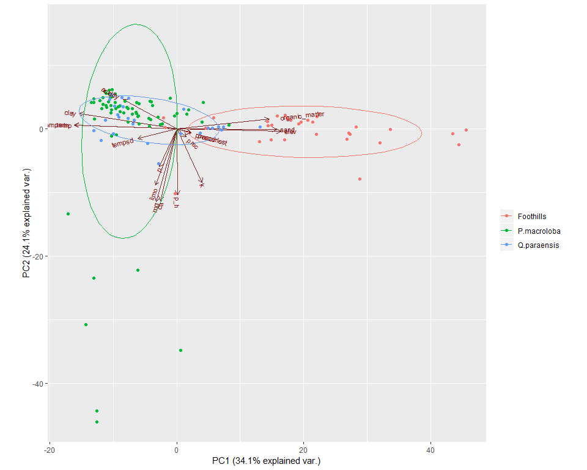

```r
pca_envi <- prcomp(denvi_est[,2:18], scale. = TRUE)
ggbiplot(pca_envi, obs.scale = 3, var.scale = 3,
  groups = dfull_est$forest_type, ellipse = TRUE) +
  scale_color_discrete(name = '') +
  theme(legend.direction = 'horizontal', legend.position = 'top')+
  theme_grey()
```

## Correlaciones Redundancy vrs Environment

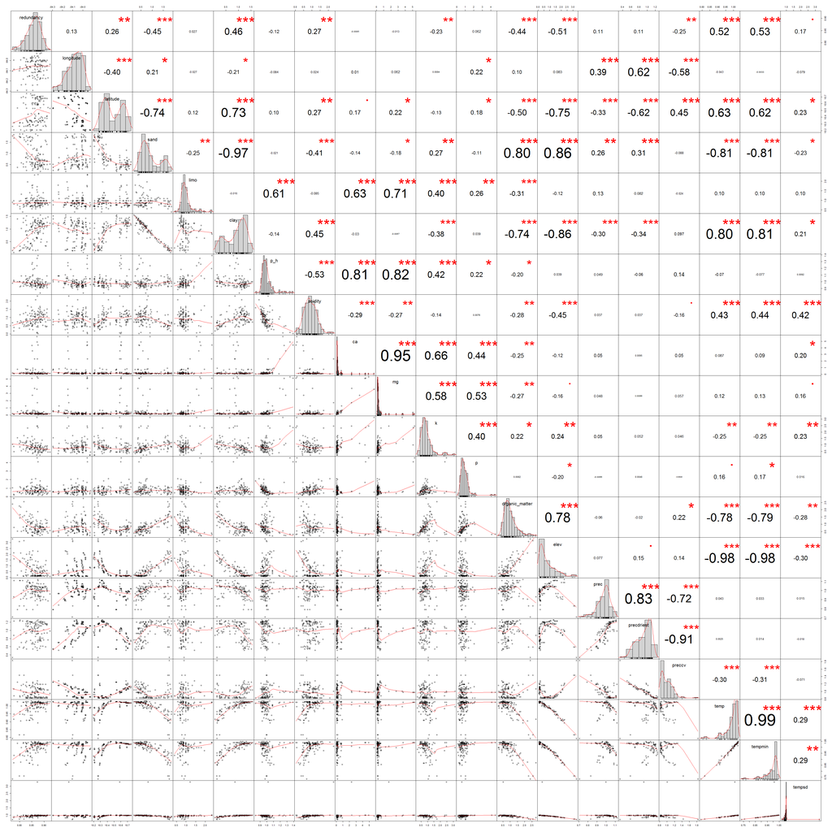

```r
chart.Correlation(dfull_est[,c(8,3,4, 11:27)], histogram=TRUE, pch="+")
```

## VIFs

```r
corvif(dfull_est[,c(3,4,11:27)])
```

```
##
##
## Variance inflation factors
##
##                        GVIF
## longitude      3.003471e+00
## latitude       1.730260e+01
## sand           2.809899e+07
## limo           1.915980e+06
## clay           2.641092e+07
## p_h            6.828257e+00
## acidity        3.075751e+00
## ca             1.956259e+01
## mg             2.402243e+01
## k              3.826313e+00
## p              2.402285e+00
## organic_matter 6.139815e+00
## elev           1.663644e+02
## prec           8.514604e+00
## precdriest     2.724207e+01
## preccv         1.958862e+01
## temp           1.164389e+02
## tempmin        1.680260e+02
## tempsd         1.662627e+00
```

## Covariables que se van a eliminar

```r
dredundancy_eff <- dfull_est %>%
  select(-c(tempsd, mg, ca, p, elev, sand, prec, preccv, tempmin, limo, p_h, u,q, crtm_90_x,crtm_90_y ))
```

- **tempsd**. Debido a que no tiene relacion con redundancy
- **mg**. Debido a que no tiene relacion con redundancy
- **ca**. Debido a que no tiene relacion con redundancy
- **p**. Debido a que no tiene relacion con redundancy
- **elev**. Debido a que tiene alto VIF, alta correlacion con Latitude y en el pca tiene la misma direccion que organic matter y sand
- **sand**. Debido a que tiene alto VIF y en el pca tiene la misma direccion que organic matter.
- **prec**. alta correlacion con predriest y en el pca tiene la misma direccion que prec.
- **preccv**. Alta correlacion con predriest, en el pca tiene la misma direccion que prec y tiene poca relacion con redundancia.
- **limo**. Tiene poca relacion con redundancia.
- **pH**. Tiene poca relacion con redundancia.

### VIFs sin variables eliminadas

```r
ncol(dredundancy_eff)
```

```
## [1] 12
```

```r
corvif(dredundancy_eff[,c(3,4,7:12)])
```

```
##
##
## Variance inflation factors
##
##                    GVIF
## longitude      1.730507
## latitude       4.888690
## clay           6.824637
## acidity        1.420020
## k              1.273537
## organic_matter 3.456373
## precdriest     4.690756
## temp           5.962413
```

## Cleveland plot

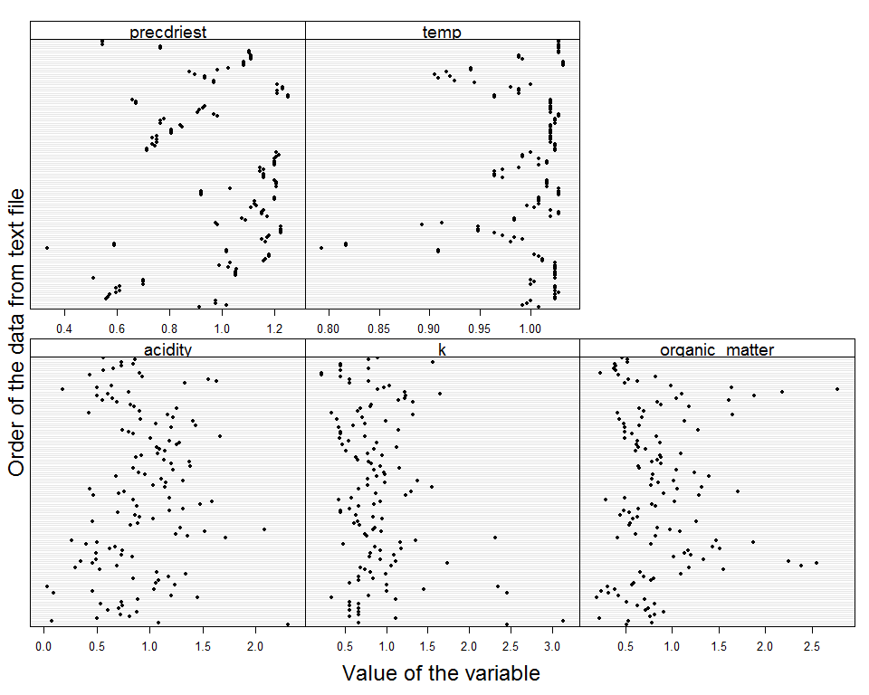

```r
Mydotplot(dredundancy_eff[, 8:12])
```

# Model formulation

$$redundancia \sim N(\mu_i, \sigma^2)$$

$$E(redundancia)=\mu_i ,var(redundancia)=\sigma^2$$

```r
glimpse(dredundancy_eff)
```

```
## Observations: 127
## Variables: 12
## $ plot           <chr> "F10P1", "F10P2", "F10P3", "F10P4", "F11P1", "F...
## $ forest_type    <fct> P.macroloba, P.macroloba, P.macroloba, P.macrol...
## $ longitude      <dbl> -84.13907, -84.14223, -84.14690, -84.14741, -84...
## $ latitude       <dbl> 10.58515, 10.58890, 10.58497, 10.58649, 10.7037...
## $ n              <int> 12, 19, 13, 15, 21, 20, 17, 15, 13, 16, 15, 16,...
## $ redundancy     <dbl> 0.8725523, 0.8979476, 0.8711145, 0.8523120, 0.8...
## $ clay           <dbl> 0.8581029, 1.0172463, 0.6594220, 0.8978391, 1.2...
## $ acidity        <dbl> 2.31038300, 1.08199755, 0.07001161, 0.49962828,...
## $ k              <dbl> 2.4588529, 0.6705962, 3.1294491, 1.1176604, 0.5...
## $ organic_matter <dbl> 0.5100446, 0.7900463, 0.5344431, 0.2207482, 0.7...
## $ precdriest     <dbl> 0.9154796, 1.0164516, 0.9760628, 0.9760628, 0.5...
## $ temp           <dbl> 1.0078616, 0.9919898, 0.9959578, 0.9999257, 1.0...
```

## Model R-INLA

```r
mnull <- inla(redundancy ~ longitude + latitude,
           family = "gaussian",
           control.predictor = list(
             compute = TRUE,
             quantiles = c(0.025, 0.975)
           ),
           control.compute = list(dic = TRUE,
                                  waic =TRUE),
           data = dredundancy_eff)

m1 <- inla(redundancy ~ forest_type ,
           family = "gaussian",
           control.predictor = list(
             compute = TRUE,
             quantiles = c(0.025, 0.975)
           ),
           control.compute = list(dic = TRUE,
                                  waic =TRUE),
           data = dredundancy_eff)



m2 <- inla(redundancy ~ forest_type + clay ,
           family = "gaussian",
           control.predictor = list(
             compute = TRUE,
             quantiles = c(0.025, 0.975)
           ),
           control.compute = list(dic = TRUE,
                                  waic =TRUE),
           data = dredundancy_eff)

mcompleto <- inla(redundancy ~ forest_type + longitude + latitude + clay + acidity +
             k + organic_matter + precdriest + temp,
           family = "gaussian",
           control.predictor = list(
             compute = TRUE,
             quantiles = c(0.025, 0.975)
           ),
           control.compute = list(dic = TRUE,
                                  waic =TRUE),
           data = dredundancy_eff)

mcompleto_interac <- inla(redundancy ~ forest_type * longitude +  forest_type*latitude + forest_type*clay + forest_type*acidity +
             forest_type*k + forest_type*organic_matter + forest_type*precdriest + forest_type*temp,
           family = "gaussian",
           control.predictor = list(
             compute = TRUE,
             quantiles = c(0.025, 0.975)
           ),
           control.compute = list(dic = TRUE,
                                  waic =TRUE),
           data = dredundancy_eff)
```

# Model selection

#### DIC

```r
mnull$dic$dic
```

```
## [1] -527.7513
```

```r
m1$dic$dic
```

```
## [1] -551.5865
```

```r
m2$dic$dic
```

```
## [1] -550.5398
```

```r
#m3$dic$dic
mcompleto$dic$dic
```

```
## [1] -547.639
```

```r
mcompleto_interac$dic$dic
```

```
## [1] -545.284
```

#### WAIC

```r
mnull$waic$waic
```

```
## [1] -527.7029
```

```r
m1$waic$waic
```

```
## [1] -551.0271
```

```r
m2$waic$waic
```

```
## [1] -549.5509
```

```r
#m3$waic$waic
mcompleto$waic$waic
```

```
## [1] -546.1092
```

```r
mcompleto_interac$waic$waic
```

```
## [1] -543.5125
```

## Numerical outputs for the Betas

```r
betanull <- mnull$summary.fixed[,c("mean","sd", "0.025quant","0.975quant")]
kable(betanull,digits = 3) %>%
  kable_styling(bootstrap_options = c("striped", "hover", "condensed"),full_width = F)
```

|  | mean | sd | 0.025quant | 0.975quant |
| --- | --- | --- | --- | --- |
| (Intercept) | 9.329 | 2.931 | 3.564 | 15.088 |
| longitude | 0.109 | 0.036 | 0.039 | 0.179 |
| latitude | 0.066 | 0.016 | 0.034 | 0.099 |

```r
beta1 <- m1$summary.fixed[,c("mean","sd", "0.025quant","0.975quant")]
kable(beta1,digits = 3) %>%
  kable_styling(bootstrap_options = c("striped", "hover", "condensed"),full_width = F)
```

|  | mean | sd | 0.025quant | 0.975quant |
| --- | --- | --- | --- | --- |
| (Intercept) | 0.834 | 0.005 | 0.824 | 0.843 |
| forest_typeP.macroloba | 0.041 | 0.006 | 0.029 | 0.052 |
| forest_typeQ.paraensis | 0.027 | 0.007 | 0.014 | 0.041 |

```r
beta2 <- m2$summary.fixed[,c("mean","sd", "0.025quant","0.975quant")]
kable(beta2,digits = 3) %>%
  kable_styling(bootstrap_options = c("striped", "hover", "condensed"),full_width = F)
```

|  | mean | sd | 0.025quant | 0.975quant |
| --- | --- | --- | --- | --- |
| (Intercept) | 0.830 | 0.006 | 0.819 | 0.842 |
| forest_typeP.macroloba | 0.033 | 0.010 | 0.014 | 0.052 |
| forest_typeQ.paraensis | 0.021 | 0.010 | 0.002 | 0.040 |
| clay | 0.009 | 0.010 | -0.010 | 0.029 |

```r
betacompleto_interac <- mcompleto_interac$summary.fixed[,c("mean","sd", "0.025quant","0.975quant")]
kable(betacompleto_interac,digits = 3) %>%
  kable_styling(bootstrap_options = c("striped", "hover", "condensed"),full_width = F)
```

|  | mean | sd | 0.025quant | 0.975quant |
| --- | --- | --- | --- | --- |
| (Intercept) | -12.564 | 9.544 | -31.229 | 6.276 |
| forest_typeP.macroloba | 15.075 | 10.701 | -6.069 | 36.002 |
| forest_typeQ.paraensis | 36.899 | 15.443 | 6.341 | 67.039 |
| longitude | -0.199 | 0.136 | -0.464 | 0.069 |
| latitude | -0.344 | 0.247 | -0.829 | 0.143 |
| clay | 0.049 | 0.037 | -0.024 | 0.122 |
| acidity | -0.027 | 0.024 | -0.074 | 0.021 |
| k | 0.002 | 0.016 | -0.030 | 0.035 |
| organic_matter | -0.020 | 0.015 | -0.049 | 0.009 |
| precdriest | -0.004 | 0.074 | -0.150 | 0.142 |
| temp | 0.248 | 0.331 | -0.404 | 0.899 |
| forest_typeP.macroloba:longitude | 0.222 | 0.146 | -0.067 | 0.507 |
| forest_typeQ.paraensis:longitude | 0.468 | 0.189 | 0.093 | 0.837 |
| forest_typeP.macroloba:latitude | 0.403 | 0.251 | -0.094 | 0.895 |
| forest_typeQ.paraensis:latitude | 0.177 | 0.269 | -0.353 | 0.703 |
| forest_typeP.macroloba:clay | -0.040 | 0.045 | -0.128 | 0.048 |
| forest_typeQ.paraensis:clay | -0.112 | 0.057 | -0.224 | 0.000 |
| forest_typeP.macroloba:acidity | 0.028 | 0.026 | -0.023 | 0.079 |
| forest_typeQ.paraensis:acidity | 0.053 | 0.034 | -0.013 | 0.119 |
| forest_typeP.macroloba:k | -0.012 | 0.018 | -0.048 | 0.024 |
| forest_typeQ.paraensis:k | -0.030 | 0.028 | -0.085 | 0.024 |
| forest_typeP.macroloba:organic_matter | 0.037 | 0.022 | -0.006 | 0.081 |
| forest_typeQ.paraensis:organic_matter | -0.006 | 0.037 | -0.079 | 0.067 |
| forest_typeP.macroloba:precdriest | 0.026 | 0.083 | -0.136 | 0.189 |
| forest_typeQ.paraensis:precdriest | -0.126 | 0.118 | -0.356 | 0.106 |
| forest_typeP.macroloba:temp | -0.623 | 0.488 | -1.582 | 0.338 |
| forest_typeQ.paraensis:temp | 0.820 | 0.827 | -0.802 | 2.450 |

## Numerical outputs for the hyperparameters

### Precision($\tau$)

```r
kable(m1$summary.hyperpar,digits = 3) %>%
  kable_styling(bootstrap_options = c("striped", "hover", "condensed"),full_width = F)
```

|  | mean | sd | 0.025quant | 0.5quant | 0.975quant | mode |
| --- | --- | --- | --- | --- | --- | --- |
| Precision for the Gaussian observations | 1400.825 | 177.729 | 1074.704 | 1393.079 | 1770.806 | 1377.648 |

### Convertir posterior mean $\tau$ a posterior mean $\sigma$

```r
tau <- m1$marginals.hyperpar$`Precision for the Gaussian observations`
#m1$marginals.hyperpar[[1]]

MySqrt <- function(x){1/sqrt(x)}
(sigma <- inla.emarginal(MySqrt,tau))
```

```
## [1] 0.02688236
```

## Graphical output for the hyperparameters

### Posterior marginal distribution of $\tau$

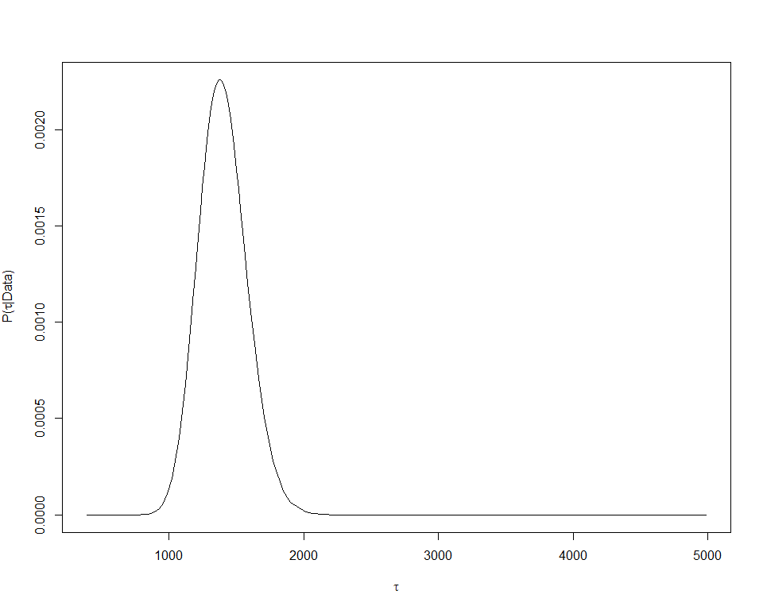

```r
tau <- m1$marginals.hyperpar$`Precision for the Gaussian observations`
plot(tau[,1], tau[,2], type="l",
     xlab = expression(tau),
     ylab = expression(paste("P(",tau,"|Data)")))
```

### Spline smoothing applied on the posterior marginal distribution of $\tau$

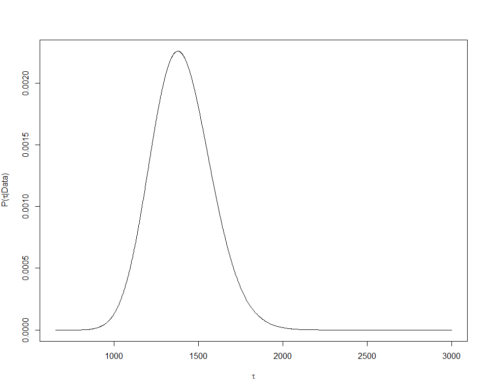

```r
tau.distr <- inla.smarginal(tau)
plot(tau.distr$x, tau.distr$y, type="l",
     xlab = expression(tau),
     ylab = expression(paste("P(",tau,"|Data)")))
```

### Posterior marginal distribution of $\sigma$

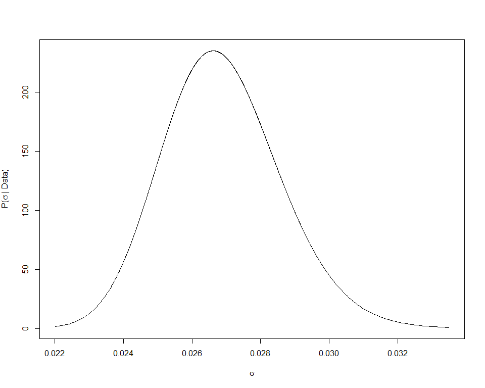

```r
sigma.distr <- inla.tmarginal(fun = MySqrt,
                              marg = tau)
plot(x = sigma.distr[,1],
     y = sigma.distr[,2],
     type = "l",
     xlab = expression(sigma),
     ylab = expression(paste("P(", sigma ," | Data)")))
text(0.86, 8.2, "C", cex = 1.5)
```

# Fitted Model

# Model validation

## Calculating the residuals in R-INLA

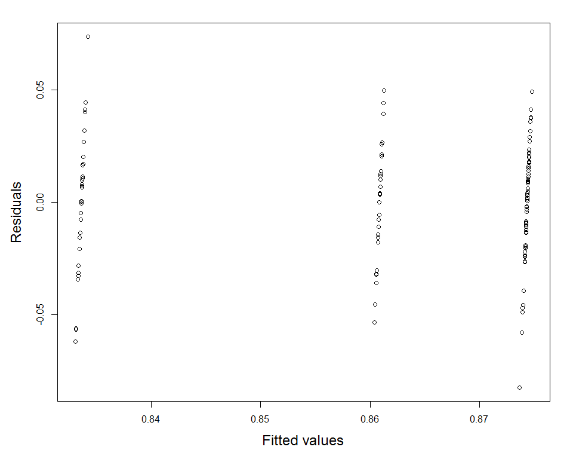

```r
Fit <- m1$summary.fitted.values[,"mean"]
E1 <- dredundancy_eff$redundancy - Fit

par(mar = c(5, 5, 2, 2), cex.lab = 1.5)

plot(x = Fit,
     y = E1,
     xlab = "Fitted values",
     ylab = "Residuals")
```

```r
range(dredundancy_eff$redundancy)
```

```
## [1] 0.7710738 0.9240270
```

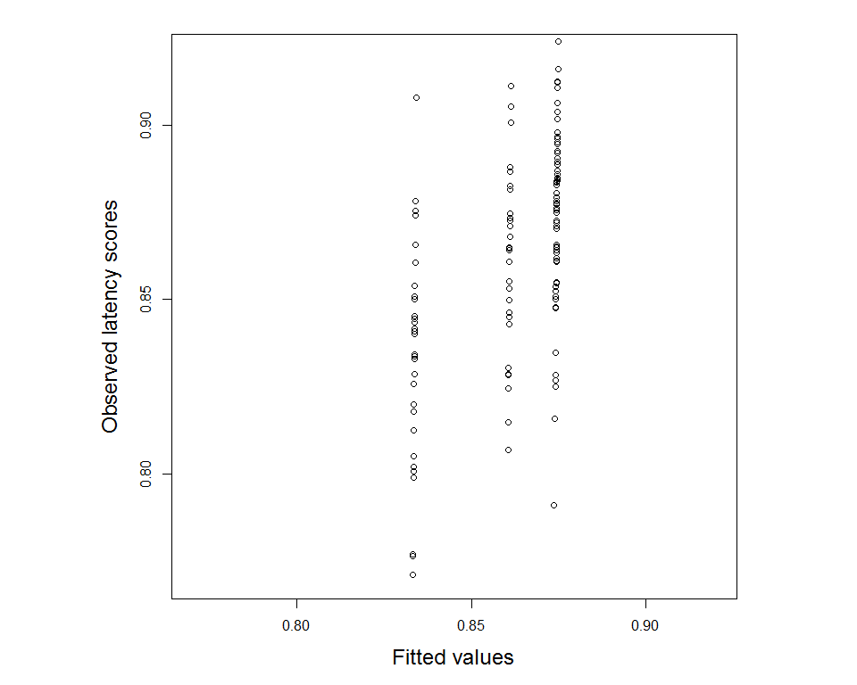

```r
par(mar = c(5, 5, 2, 2), cex.lab = 1.5, pty = "s")
plot(x = Fit,
     xlim = c(0.77, .92),
     ylim = c(0.77, .92),
     y = dredundancy_eff$redundancy,
     xlab = "Fitted values",
     ylab = "Observed latency scores")
```

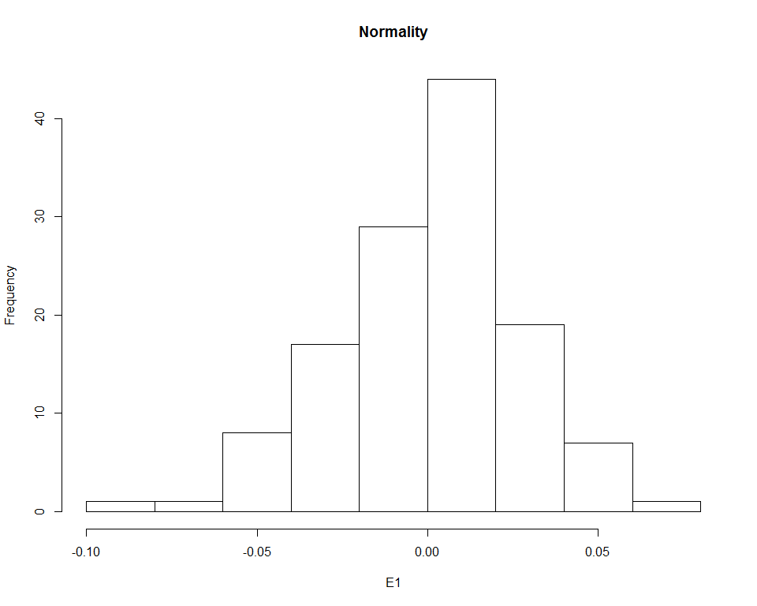

```r
hist(E1, main = "Normality", breaks=10)
```

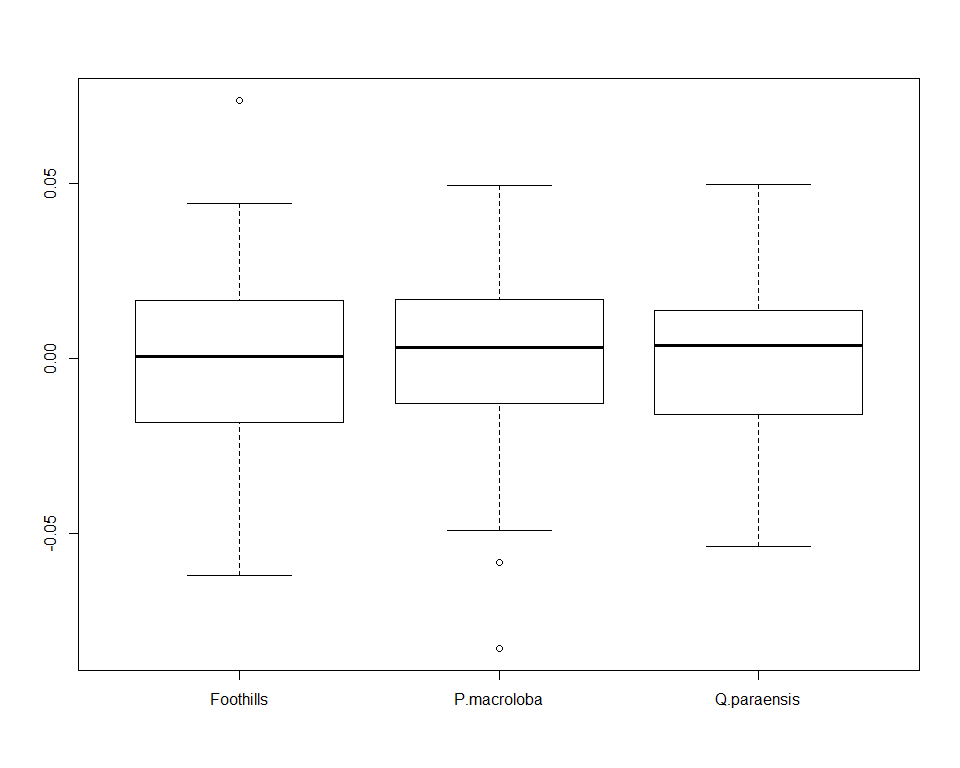

```r
#Plot residuals versus covariates
plot(x = dredundancy_eff$forest_type,
     y = E1)
```

##### Importante:

There is the **number of equivalent replicates**. We have a sample size (n) and the model regression parameters (p) . A general recommendation on statistics is to have al least 15 obsevations per parameter (n/p = 15 )